# Dari Data menuju Informasi Strategis

Tata Kelola Data untuk Mendukung Pengambilan Keputusan di Sektor Kelautan dan Perikanan

## Panduan Akses Data Resmi KKP

**Materi ini menampilkan hasil analisis, tabel, dan grafik untuk pembelajaran.** File dataset mentah `.csv` atau `.xlsx` tidak tersedia di repository GitHub ini.

Untuk mempraktikkan kode R dan melakukan analisis ulang, peserta diminta **mengakses dan mengunduh data sendiri dari portal resmi KKP**:

[Buka Portal Satu Data KKP ↗](https://portaldata.kkp.go.id/) [Tabel dinamis produksi perikanan ↗](https://portaldata.kkp.go.id/portals/data-statistik/prod-ikan/tbl-dinamis?filter_utama=1&tahun=2023)

Catatan: sesuaikan periode, jenis perikanan, nama variabel, satuan, dan format hasil unduhan dengan contoh kode di `KKP.Rmd`. Hasil pada halaman ini bersumber dari data yang digunakan ketika materi disusun, sehingga dapat berbeda dengan dataset yang diunduh sekarang.

## Executive Summary

Paparan ini mendemonstrasikan bagaimana manajemen data yang terstruktur dapat mengubah *raw data* yang rentan anomali menjadi **Informasi Strategis** yang siap mendukung pengambilan keputusan di Kementerian Kelautan dan Perikanan (KKP). Seluruh proses—mulai dari entri, *coding*, hingga agregasi—diperagakan menggunakan bahasa pemrograman R.

## 1. Entry dan Coding Data

### a. Proses Penyiapan Data

Langkah pertama dalam manajemen data adalah membaca dan membersihkan struktur awal data agar seragam dan mudah diolah oleh sistem basis data maupun perangkat lunak analitik.

```r
# 1. Membaca data asli (Tanpa clean_names)
file_path <- "Produksi Perikanan Tangkap.csv"

data_raw <- read_csv(file_path, skip = 1)

# 2. Menerapkan clean_names()
data_tangkap <- data_raw %>% clean_names()

# 3. Menyusun tabel perbandingan nama kolom
compare <- tibble(
  `Nama Kolom Asli (Raw CSV)` = names(data_raw),
  `Hasil clean_names()` = names(data_tangkap)
)

# Menampilkan tabel perbandingan
kable(compare, caption = "Tabel Perbandingan Transformasi Nama Kolom Data Produksi Perikanan Tangkap")
```

Tabel Perbandingan Transformasi Nama Kolom Data Produksi Perikanan Tangkap

| Nama Kolom Asli (Raw CSV) | Hasil clean_names() |
| --- | --- |
| Tahun | tahun |
| Provinsi | provinsi |
| Kab / Kota | kab_kota |
| Kelompok Ikan | kelompok_ikan |
| Jenis Ikan | jenis_ikan |
| Jenis Usaha | jenis_usaha |
| Volume (ton) | volume_ton |
| Nilai (Rp. Juta) | nilai_rp_juta |
| Harga Rata-Rata Tertimbang (Rp/kg) | harga_rata_rata_tertimbang_rp_kg |

### b. Eksplorasi Peubah

```r
library(skimr)

# Menampilkan ringkasan menyeluruh
skim(data_tangkap)
```

Data summary

| Name | data_tangkap |
| --- | --- |
| Number of rows | 20910 |
| Number of columns | 9 |
| _______________________ |  |
| Column type frequency: |  |
| character | 5 |
| numeric | 4 |
| ________________________ |  |
| Group variables | None |

**Variable type: character**

| skim_variable | n_missing | complete_rate | min | max | empty | n_unique | whitespace |
| --- | --- | --- | --- | --- | --- | --- | --- |
| provinsi | 0 | 1 | 4 | 26 | 0 | 38 | 0 |
| kab_kota | 0 | 1 | 4 | 32 | 0 | 485 | 0 |
| kelompok_ikan | 0 | 1 | 3 | 13 | 0 | 145 | 0 |
| jenis_ikan | 0 | 1 | 3 | 35 | 0 | 816 | 0 |
| jenis_usaha | 0 | 1 | 4 | 14 | 0 | 2 | 0 |

**Variable type: numeric**

| skim_variable | n_missing | complete_rate | mean | sd | p0 | p25 | p50 | p75 | p100 | hist |
| --- | --- | --- | --- | --- | --- | --- | --- | --- | --- | --- |
| tahun | 0 | 1 | 2024.00 | 0.00 | 2024 | 2024.00 | 2024.00 | 2024.00 | 2024.00 | ▁▁▇▁▁ |
| volume_ton | 0 | 1 | 373.58 | 1366.36 | 0 | 4.46 | 39.69 | 252.26 | 55319.89 | ▇▁▁▁▁ |
| nilai_rp_juta | 0 | 1 | 10465.01 | 40150.50 | 0 | 101.00 | 995.00 | 6424.00 | 2255774.00 | ▇▁▁▁▁ |
| harga_rata_rata_tertimbang_rp_kg | 0 | 1 | 31346.34 | 31401.30 | 1000 | 16319.25 | 25000.00 | 37277.50 | 800000.00 | ▇▁▁▁▁ |

### b. Proses Entri Data

Entri data manual (tanpa sistem *dropdown*) berisiko menghasilkan ketidakkonsistenan penulisan. Berikut adalah cuplikan data hasil entri awal.

```r
data_tangkap %>%
  select(provinsi, kab_kota, jenis_ikan, volume_ton, nilai_rp_juta) %>%
  head(20) %>%
  kable(caption = "Tabel 1. Cuplikan Raw Data Produksi Perikanan")
```

Tabel 1. Cuplikan Raw Data Produksi Perikanan

| provinsi | kab_kota | jenis_ikan | volume_ton | nilai_rp_juta |
| --- | --- | --- | --- | --- |
| DKI JAKARTA | KOTA ADMINISTRASI JAKARTA UTARA | CUMI-CUMI | 55319.89 | 2255774 |
| MALUKU | MALUKU TENGAH | LAYANG JEPANG | 47839.63 | 452691 |
| SULAWESI SELATAN | BONE | RAJUNGAN BIASA | 34657.83 | 1213024 |
| SULAWESI UTARA | KOTA BITUNG | CAKALANG | 33172.95 | 712402 |
| KEPULAUAN RIAU | NATUNA | KERAPU KARANG | 33092.58 | 1158240 |
| JAWA TENGAH | KOTA TEGAL | PEPEREK | 31694.11 | 88095 |
| JAWA TENGAH | PATI | LAYANG ANGGUR | 31523.46 | 435321 |
| PAPUA | KOTA JAYAPURA | TUNA SIRIP KUNING | 30326.19 | 1032528 |
| DKI JAKARTA | KOTA ADMINISTRASI JAKARTA UTARA | CAKALANG | 29172.94 | 269273 |
| RIAU | ROKAN HILIR | KERANG DARAH | 26570.58 | 478270 |
| JAWA BARAT | INDRAMAYU | TENGGIRI | 25439.30 | 1206958 |
| JAWA BARAT | INDRAMAYU | TONGKOL ABU-ABU | 25303.21 | 441209 |
| JAWA TENGAH | PATI | SIRO | 24389.55 | 195867 |
| JAWA TENGAH | KOTA TEGAL | CUMI-CUMI | 23276.15 | 506839 |
| MALUKU UTARA | PULAU MOROTAI | TUNA SIRIP KUNING | 22753.96 | 519070 |
| JAWA TENGAH | REMBANG | SWANGGI BINTIK UNGU | 22604.50 | 452090 |
| BALI | JEMBRANA | LEMURU | 22501.33 | 101936 |
| SULAWESI UTARA | KOTA BITUNG | TUNA SIRIP KUNING | 21711.79 | 898815 |
| BALI | KARANGASEM | TONGKOL KRAI | 20475.34 | 307130 |
| LAMPUNG | LAMPUNG TIMUR | KEMBUNG GEPENG | 20384.20 | 383608 |

### c. Proses Coding Data

Untuk menjaga integritas data dan mempercepat pencarian basis data, kita perlu melakukan *coding* (membuat kodifikasi standar). Contohnya, mengubah variabel teks menjadi kode numerik.

```r
data_tangkap <- data_tangkap %>%
  mutate(
    kode_usaha = case_when(
      str_detect(toupper(jenis_usaha), "LAUT") ~ 10,
      str_detect(toupper(jenis_usaha), "DARATAN|PUD") ~ 20,
      TRUE ~ 99
    )
  )

data_tangkap %>%
  select(jenis_usaha, kode_usaha) %>%
  distinct() %>%
  kable(caption = "Tabel 2. Hasil Master Data Coding Jenis Usaha")
```

Tabel 2. Hasil Master Data Coding Jenis Usaha

| jenis_usaha | kode_usaha |
| --- | --- |
| LAUT | 10 |
| PERAIRAN DARAT | 99 |

## 2. Bekerja dengan Satu Tabel Data

Proses manajemen data beralih ke ekstraksi informasi spesifik melalui pemfilteran dan agregasi.

### a. Pemfilteran pada Satu Peubah

Pimpinan meminta laporan data produksi khusus wilayah **DKI JAKARTA**.

```r
data_dki <- data_tangkap %>%
  filter(provinsi == "DKI JAKARTA")

data_dki %>%
  select(kab_kota, kelompok_ikan, volume_ton) %>%
  head(5) %>%
  kable()
```

| kab_kota | kelompok_ikan | volume_ton |
| --- | --- | --- |
| KOTA ADMINISTRASI JAKARTA UTARA | CUMI-CUMI | 55319.89 |
| KOTA ADMINISTRASI JAKARTA UTARA | CAKALANG | 29172.94 |
| KOTA ADMINISTRASI JAKARTA UTARA | TUNA | 11305.85 |
| KOTA ADMINISTRASI JAKARTA UTARA | LAYANG | 8679.26 |
| KOTA ADMINISTRASI JAKARTA UTARA | TUNA | 8551.94 |

### b. Pemfilteran pada Dua Peubah

Mencari data yang lebih sempit: Produksi **“CAKALANG”** di **SULAWESI UTARA**.

```r
data_spesifik <- data_tangkap %>%
  filter(provinsi == "SULAWESI UTARA", kelompok_ikan == "CAKALANG")

data_spesifik %>%
  select(kab_kota, jenis_ikan, volume_ton) %>%
  kable()
```

| kab_kota | jenis_ikan | volume_ton |
| --- | --- | --- |
| KOTA BITUNG | CAKALANG | 33172.95 |
| MINAHASA TENGGARA | CAKALANG | 7634.51 |
| KOTA MANADO | CAKALANG | 7527.37 |
| KEPULAUAN TALAUD | CAKALANG | 4523.20 |
| MINAHASA | CAKALANG | 3601.58 |
| BOLAANG MONGONDOW SELATAN | CAKALANG | 2980.05 |
| BOLAANG MONGONDOW | CAKALANG | 2451.18 |
| BOLAANG MONGONDOW TIMUR | CAKALANG | 1951.59 |
| KEPULAUAN SIAU TAGULANDANG BIARO | CAKALANG | 1817.16 |
| KEPULAUAN SANGIHE | CAKALANG | 1341.48 |
| BOLAANG MONGONDOW UTARA | CAKALANG | 1062.37 |
| MINAHASA UTARA | CAKALANG | 1052.52 |
| MINAHASA SELATAN | CAKALANG | 1038.64 |

### c. Agregasi Data

Mengubah baris transaksi menjadi ringkasan level provinsi untuk presentasi pimpinan.

```r
rekap_provinsi <- data_tangkap %>%
  group_by(provinsi) %>%
  summarise(
    total_volume_ton = sum(volume_ton, na.rm = TRUE),
    total_nilai_juta = sum(nilai_rp_juta, na.rm = TRUE)
  ) %>%
  arrange(desc(total_nilai_juta))

# Menampilkan menggunakan Datatable agar interaktif
datatable(rekap_provinsi, options = list(pageLength = 10)) %>%
  formatCurrency('total_nilai_juta', currency = 'Rp ', interval = 3, mark = '.', dec.mark = ',') %>%
  formatRound('total_volume_ton', digits = 2)
```

|  | provinsi | total_volume_ton | total_nilai_juta |
| --- | --- | --- | --- |
| 1 | SULAWESI SELATAN | 512484.85 | 14294287 |
| 2 | ACEH | 427639.99 | 13799492 |
| 3 | SUMATERA UTARA | 395819.52 | 11912826 |
| 4 | JAWA TIMUR | 633718.83 | 11297721 |
| 5 | MALUKU | 399142.94 | 10476381 |
| 6 | KEPULAUAN RIAU | 339329.8 | 10203653 |
| 7 | SULAWESI UTARA | 340912.45 | 9882362 |
| 8 | JAWA TENGAH | 554182.11 | 9284583 |
| 9 | KALIMANTAN SELATAN | 231591.06 | 8725670 |
| 10 | KALIMANTAN TIMUR | 216039.8 | 8350742 |

[output cut: 28 more lines]

## 3. Bekerja dengan Lebih dari Satu Tabel Data

Data KKP sering kali terdistribusi di beberapa unit eselon. Kita harus mampu merajutnya (*merging*).

```r
# Menyiapkan simulasi subset tabel untuk didemonstrasikan
tabel_volume <- data_tangkap %>% select(provinsi, kab_kota, jenis_ikan, volume_ton) %>% head(3)
tabel_nilai <- data_tangkap %>% select(provinsi, kab_kota, jenis_ikan, nilai_rp_juta) %>% head(3)

data_jawa_tengah <- data_tangkap %>% filter(provinsi == "JAWA TENGAH") %>% head(2)
data_papua <- data_tangkap %>% filter(provinsi == "PAPUA") %>% head(2)
```

```r
tabel_volume %>% kable()
```

| provinsi | kab_kota | jenis_ikan | volume_ton |
| --- | --- | --- | --- |
| DKI JAKARTA | KOTA ADMINISTRASI JAKARTA UTARA | CUMI-CUMI | 55319.89 |
| MALUKU | MALUKU TENGAH | LAYANG JEPANG | 47839.63 |
| SULAWESI SELATAN | BONE | RAJUNGAN BIASA | 34657.83 |

```r
tabel_nilai %>% kable()
```

| provinsi | kab_kota | jenis_ikan | nilai_rp_juta |
| --- | --- | --- | --- |
| DKI JAKARTA | KOTA ADMINISTRASI JAKARTA UTARA | CUMI-CUMI | 2255774 |
| MALUKU | MALUKU TENGAH | LAYANG JEPANG | 452691 |
| SULAWESI SELATAN | BONE | RAJUNGAN BIASA | 1213024 |

```r
data_jawa_tengah %>% kable()
```

| tahun | provinsi | kab_kota | kelompok_ikan | jenis_ikan | jenis_usaha | volume_ton | nilai_rp_juta | harga_rata_rata_tertimbang_rp_kg | kode_usaha |
| --- | --- | --- | --- | --- | --- | --- | --- | --- | --- |
| 2024 | JAWA TENGAH | KOTA TEGAL | PEPEREK | PEPEREK | LAUT | 31694.11 | 88095 | 2780 | 10 |
| 2024 | JAWA TENGAH | PATI | LAYANG | LAYANG ANGGUR | LAUT | 31523.46 | 435321 | 13809 | 10 |

```r
data_papua %>% kable()
```

| tahun | provinsi | kab_kota | kelompok_ikan | jenis_ikan | jenis_usaha | volume_ton | nilai_rp_juta | harga_rata_rata_tertimbang_rp_kg | kode_usaha |
| --- | --- | --- | --- | --- | --- | --- | --- | --- | --- |
| 2024 | PAPUA | KOTA JAYAPURA | TUNA | TUNA SIRIP KUNING | LAUT | 30326.19 | 1032528 | 34047 | 10 |
| 2024 | PAPUA | KOTA JAYAPURA | CAKALANG | CAKALANG | LAUT | 18776.98 | 565290 | 30105 | 10 |

### a. Menggabungkan Data Baru (Merging in New Cases)

Menyatukan file laporan mingguan dari wilayah Jawa Tengah dan Papua (menambah baris ke bawah / *Row Bind*).

```r
data_gabung_baris <- bind_rows(data_jawa_tengah, data_papua)

data_gabung_baris %>%
  select(provinsi, kab_kota, jenis_ikan, volume_ton) %>%
  kable()
```

| provinsi | kab_kota | jenis_ikan | volume_ton |
| --- | --- | --- | --- |
| JAWA TENGAH | KOTA TEGAL | PEPEREK | 31694.11 |
| JAWA TENGAH | PATI | LAYANG ANGGUR | 31523.46 |
| PAPUA | KOTA JAYAPURA | TUNA SIRIP KUNING | 30326.19 |
| PAPUA | KOTA JAYAPURA | CAKALANG | 18776.98 |

### b. Menggabungkan Peubah Baru (Merging in New Variables)

Menyatukan tabel yang berisi *Volume* dari Ditjen Tangkap dengan tabel *Nilai* dari Ditjen PDSKP berdasarkan “Kunci Wilayah dan Ikan” (*Column Join*).

```r
data_gabung_kolom <- left_join(tabel_volume, tabel_nilai,
                               by = c("provinsi", "kab_kota", "jenis_ikan"))

data_gabung_kolom %>% kable()
```

| provinsi | kab_kota | jenis_ikan | volume_ton | nilai_rp_juta |
| --- | --- | --- | --- | --- |
| DKI JAKARTA | KOTA ADMINISTRASI JAKARTA UTARA | CUMI-CUMI | 55319.89 | 2255774 |
| MALUKU | MALUKU TENGAH | LAYANG JEPANG | 47839.63 | 452691 |
| SULAWESI SELATAN | BONE | RAJUNGAN BIASA | 34657.83 | 1213024 |

### c. Menggabungkan Data

Memperkaya tabel utama dengan informasi “Zona Waktu” menggunakan tabel master/referensi

```r
# Membuat Master Data (Tabel Lookup)
tabel_master_wilayah <- tibble(
  provinsi = c("DKI JAKARTA", "JAWA TENGAH", "SULAWESI UTARA", "MALUKU", "PAPUA"),
  regional_waktu = c("WIB", "WIB", "WITA", "WIT", "WIT")
)

tabel_master_wilayah %>% kable()
```

| provinsi | regional_waktu |
| --- | --- |
| DKI JAKARTA | WIB |
| JAWA TENGAH | WIB |
| SULAWESI UTARA | WITA |
| MALUKU | WIT |
| PAPUA | WIT |

```r
# Left Join
data_dengan_regional <- data_gabung_baris %>%
  select(provinsi, jenis_ikan, volume_ton) %>%
  left_join(tabel_master_wilayah, by = "provinsi")

data_dengan_regional %>% kable()
```

| provinsi | jenis_ikan | volume_ton | regional_waktu |
| --- | --- | --- | --- |
| JAWA TENGAH | PEPEREK | 31694.11 | WIB |
| JAWA TENGAH | LAYANG ANGGUR | 31523.46 | WIB |
| PAPUA | TUNA SIRIP KUNING | 30326.19 | WIT |
| PAPUA | CAKALANG | 18776.98 | WIT |

## 4. Anomaly Database

Jika Portal Data KKP menggunakan arsitektur file datar (*Flat File* seperti Excel) dan menolak konsep **Normalisasi Relasional**, data akan rentan terhadap 3 penyakit anomali utama:

1. **Anomali Penyisipan (*Insertion Anomaly*):** Tidak bisa menginput master “Pelabuhan Perikanan Baru” jika belum ada kapal nelayan yang melakukan bongkar muat dan tercatat di sistem pada pelabuhan tersebut.
2. **Anomali Peremajaan (*Update Anomaly*):** Jika nama “CUMI-CUMI” diubah aturannya menjadi “MOLUSKA UTAMA”, admin harus mencari dan meng-*update* ratusan ribu baris data.

```r
# Ilustrasi kerentanan update pada flat file
# Jika satu baris terlewat karena salah ejaan (misal: "cumi - cumi"), maka rekap data nasional menjadi tidak valid.
data_rentan <- data_tangkap %>%
  mutate(kelompok_ikan = ifelse(provinsi == "DKI JAKARTA" & kelompok_ikan == "CUMI-CUMI",
                                "MOLUSKA UTAMA", kelompok_ikan))
```

3. **Anomali Penghapusan (*Deletion Anomaly*):** Menghapus satu baris laporan transaksi perikanan di wilayah pulau terluar berpotensi menghapus seluruh jejak nama pulau tersebut dari sistem informasi KKP.

## 5. Dashboard Informasi Strategis

Tujuan paripurna dari Manajemen Data adalah melahirkan pandangan strategis (*Strategic Insight*). Melalui grafik di bawah ini, pimpinan KKP dapat langsung melihat **Komoditas Kuadran Atas** (Kinerja Volume vs Nilai) untuk prioritas kebijakan Rencana Kerja Pemerintah (RKP) maupun penggenjotan PNBP.

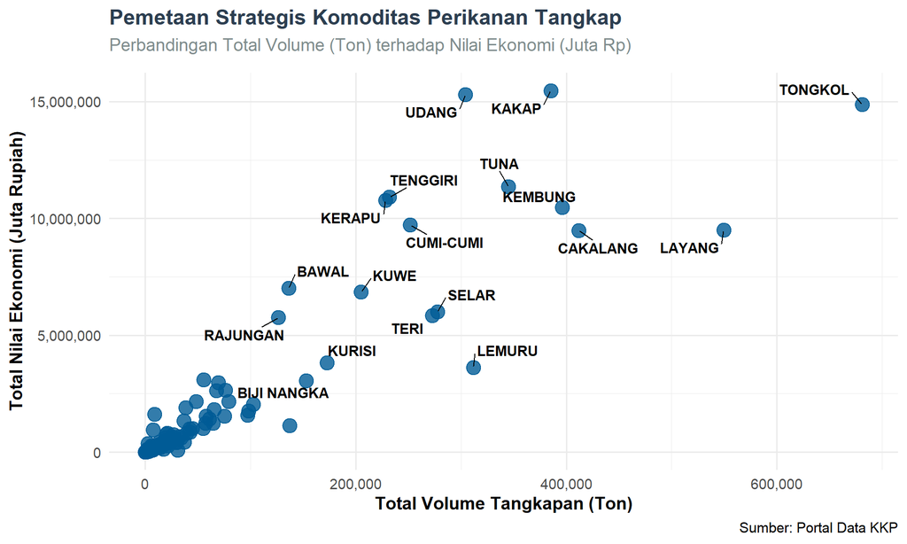

Kuadran Strategis Komoditas Kelautan dan Perikanan (Nilai vs Volume)

```r
# Menyiapkan data agregat komoditas
komoditas_strategis <- data_tangkap %>%
  group_by(kelompok_ikan) %>%
  summarise(
    total_volume = sum(volume_ton, na.rm = TRUE),
    total_nilai = sum(nilai_rp_juta, na.rm = TRUE)
  )

# Memastikan ggrepel tersedia sebelum plotting
if (requireNamespace("ggrepel", quietly = TRUE)) {

  ggplot(komoditas_strategis, aes(x = total_volume, y = total_nilai, label = kelompok_ikan)) +
    geom_point(color = "#005b96", size = 5, alpha = 0.8) +
    ggrepel::geom_text_repel(size = 4, fontface = "bold", box.padding = 0.6) +
    scale_x_continuous(labels = comma_format()) +
    scale_y_continuous(labels = comma_format()) +
    labs(
      title = "Pemetaan Strategis Komoditas Perikanan Tangkap",
      subtitle = "Perbandingan Total Volume (Ton) terhadap Nilai Ekonomi (Juta Rp)",
      x = "Total Volume Tangkapan (Ton)",
      y = "Total Nilai Ekonomi (Juta Rupiah)",
      caption = "Sumber: Portal Data KKP"
    ) +
    theme_minimal(base_size = 14) +
    theme(
      plot.title = element_text(face = "bold", color = "#2c3e50"),
      plot.subtitle = element_text(color = "#7f8c8d", margin = margin(b = 15)),
      axis.title = element_text(face = "bold")
    )

} else {
  print("Harap install package 'ggrepel' untuk melihat visualisasi yang interaktif.")
}
```

### 1. Lollipop Chart: Analisis Nilai Tambah Komoditas (Unit Value / Harga per Kg)

Informasi Strategis: Menunjukkan komoditas mana yang memiliki Unit Value (Rupiah per Kg) tertinggi. Komoditas ber-Unit Value tinggi tidak memerlukan volume tangkapan masif untuk menghasilkan nilai ekonomi tinggi, sehingga sangat relevan untuk kebijakan Penangkapan Ikan Terukur (PIT) dan proteksi spesies bernilai tinggi dari eksploitasi berlebihan (overfishing).

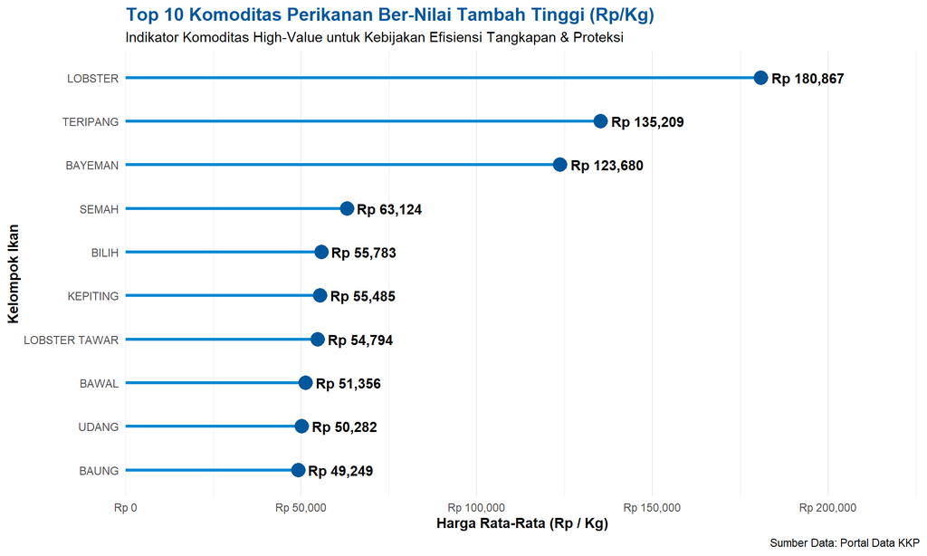

```r
# Menghitung Nilai Tambah Ekonomi (Rp/Kg) per Komoditas
harga_komoditas <- data_tangkap %>%
  group_by(kelompok_ikan) %>%
  summarise(
    total_volume = sum(volume_ton, na.rm = TRUE),
    total_nilai_juta = sum(nilai_rp_juta, na.rm = TRUE),
    harga_per_kg = (total_nilai_juta * 1000) / total_volume, # Konversi ke Rp/Kg
    .groups = "drop"
  ) %>%
  filter(total_volume > 500) %>% # Memfilter komoditas berskala signifikan
  arrange(desc(harga_per_kg)) %>%
  head(10)

# Visualisasi Lollipop Chart
ggplot(harga_komoditas, aes(x = reorder(kelompok_ikan, harga_per_kg), y = harga_per_kg)) +
  geom_segment(aes(xend = kelompok_ikan, yend = 0), color = "#0288d1", linewidth = 1.2) +
  geom_point(color = "#01579b", size = 5) +
  geom_text(aes(label = paste0("Rp ", comma(round(harga_per_kg)))),
            hjust = -0.15, size = 3.8, fontface = "bold") +
  coord_flip() +
  scale_y_continuous(labels = comma_format(prefix = "Rp "), expand = expansion(mult = c(0, 0.25))) +
  labs(
    title = "Top 10 Komoditas Perikanan Ber-Nilai Tambah Tinggi (Rp/Kg)",
    subtitle = "Indikator Komoditas High-Value untuk Kebijakan Efisiensi Tangkapan & Proteksi",
    x = "Kelompok Ikan",
    y = "Harga Rata-Rata (Rp / Kg)",
    caption = "Sumber Data: Portal Data KKP"
  ) +
  theme_minimal() +
  theme(
    plot.title = element_text(face = "bold", size = 14, color = "#01579b"),
    panel.grid.major.y = element_blank(),
    axis.title = element_text(face = "bold")
  )
```

### 2. *Heatmap Matrix*: Pemetaan Sentra Produksi & Komoditas Unggulan Wilayah

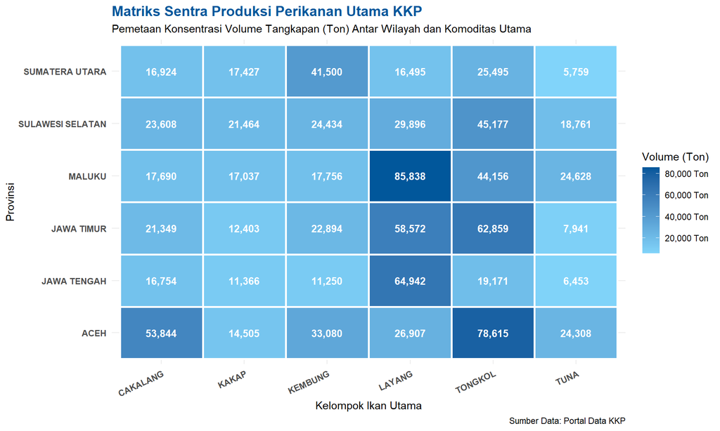

```r
# Mengambil Top 6 Provinsi & Top 6 Komoditas Terbesar
top_prov <- data_tangkap %>%
  group_by(provinsi) %>%
  summarise(vol = sum(volume_ton, na.rm = TRUE)) %>%
  slice_max(vol, n = 6) %>% pull(provinsi)

top_ikan <- data_tangkap %>%
  group_by(kelompok_ikan) %>%
  summarise(vol = sum(volume_ton, na.rm = TRUE)) %>%
  slice_max(vol, n = 6) %>% pull(kelompok_ikan)

matriks_produksi <- data_tangkap %>%
  filter(provinsi %in% top_prov, kelompok_ikan %in% top_ikan) %>%
  group_by(provinsi, kelompok_ikan) %>%
  summarise(total_volume = sum(volume_ton, na.rm = TRUE), .groups = "drop")

# Visualisasi Heatmap
ggplot(matriks_produksi, aes(x = kelompok_ikan, y = provinsi, fill = total_volume)) +
  geom_tile(color = "white", linewidth = 1) +
  geom_text(aes(label = comma(round(total_volume))), color = "white", fontface = "bold", size = 3.5) +
  scale_fill_gradient(low = "#81d4fa", high = "#01579b", labels = comma_format(suffix = " Ton")) +
  labs(
    title = "Matriks Sentra Produksi Perikanan Utama KKP",
    subtitle = "Pemetaan Konsentrasi Volume Tangkapan (Ton) Antar Wilayah dan Komoditas Utama",
    x = "Kelompok Ikan Utama",
    y = "Provinsi",
    fill = "Volume (Ton)",
    caption = "Sumber Data: Portal Data KKP"
  ) +
  theme_minimal() +
  theme(
    plot.title = element_text(face = "bold", size = 14, color = "#01579b"),
    axis.text.x = element_text(angle = 25, hjust = 1, face = "bold"),
    axis.text.y = element_text(face = "bold")
  )
```

### 3. *100% Stacked Bar Chart*: Disparitas Sumber Daya (Perikanan Laut vs. Perairan Umum Daratan / PUD)

- **Informasi Strategis:** Memetakan proporsi ketergantungan wilayah terhadap hasil Laut vs Perairan Umum Daratan (danau, sungai, waduk). Ini memberi sinyal strategis bagi Direktorat Jenderal terkait untuk menyeimbangkan program konservasi perairan pedalaman (*restocking* benih) vs modernisasi nelayan tangkap laut.

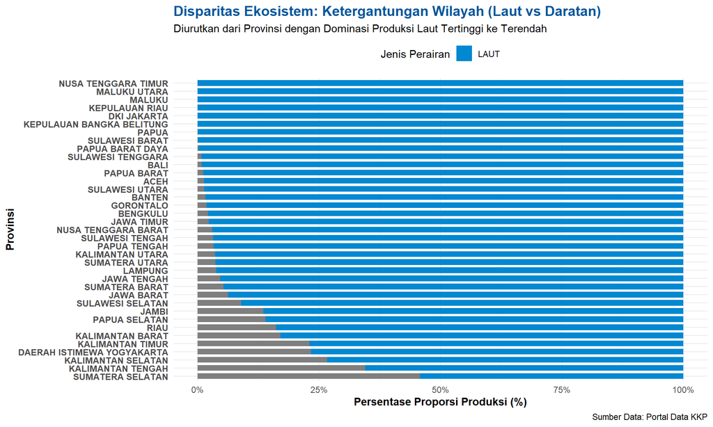

```r
# 1. Rekapitulasi Proporsi dan Perhitungan Persentase Laut per Provinsi
prop_pud <- data_tangkap %>%
  # Mengelompokkan berdasarkan Provinsi dan Jenis Usaha
  group_by(provinsi, jenis_usaha) %>%
  summarise(total_volume = sum(volume_ton, na.rm = TRUE), .groups = "drop") %>%
  # Memfilter Provinsi yang volumenya sangat kecil agar grafik tidak terlalu padat
  group_by(provinsi) %>%
  filter(sum(total_volume) > 5000) %>%
  # Menghitung Persentase Laut untuk digunakan sebagai pengurut (sorting)
  mutate(
    persentase_laut = ifelse(jenis_usaha == "LAUT",
                             total_volume / sum(total_volume),
                             0)
  ) %>%
  # Mengambil nilai persentase_laut terbesar untuk disematkan ke nama provinsi
  mutate(sort_value = max(persentase_laut)) %>%
  ungroup()

# 2. Visualisasi Stacked Bar 100% yang Terurut
ggplot(prop_pud, aes(x = reorder(provinsi, sort_value), y = total_volume, fill = jenis_usaha)) +
  geom_col(position = "fill", width = 0.7) +
  scale_y_continuous(labels = percent_format()) +
  # Memilih warna kontras yang representatif (Biru Laut & Hijau Darat)
  scale_fill_manual(values = c("LAUT" = "#0288d1", "PERAIRAN UMUM DARATAN" = "#66bb6a")) +
  coord_flip() +
  labs(
    title = "Disparitas Ekosistem: Ketergantungan Wilayah (Laut vs Daratan)",
    subtitle = "Diurutkan dari Provinsi dengan Dominasi Produksi Laut Tertinggi ke Terendah",
    x = "Provinsi",
    y = "Persentase Proporsi Produksi (%)",
    fill = "Jenis Perairan",
    caption = "Sumber Data: Portal Data KKP"
  ) +
  theme_minimal() +
  theme(
    plot.title = element_text(face = "bold", size = 14, color = "#01579b"),
    legend.position = "top",
    axis.text.y = element_text(face = "bold", size = 9), # Mempertegas nama provinsi
    axis.title = element_text(face = "bold")
  )
```

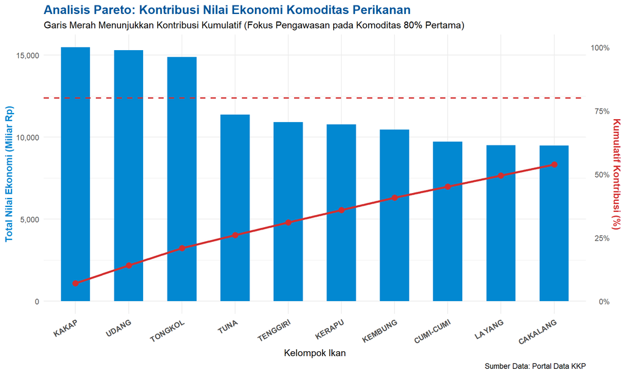

```r
# 1. Menyiapkan Data Pareto dengan Konversi Miliar Rp yang Aman
pareto_data <- data_tangkap %>%
  mutate(nilai_rp_juta = as.numeric(nilai_rp_juta)) %>% # Memastikan tipe data numerik
  group_by(kelompok_ikan) %>%
  summarise(
    total_nilai_miliar = sum(nilai_rp_juta, na.rm = TRUE) / 1000, # Langsung konversi ke Miliar Rp
    .groups = "drop"
  ) %>%
  arrange(desc(total_nilai_miliar)) %>%
  mutate(
    persen_kumulatif = cumsum(total_nilai_miliar) / sum(total_nilai_miliar) * 100,
    peringkat = row_number()
  ) %>%
  filter(peringkat <= 10)

# 2. Mengambil Nilai Maksimum secara Aman
max_nilai_miliar <- max(pareto_data$total_nilai_miliar, na.rm = TRUE)

# 3. Visualisasi Kurva Pareto Dual-Axis
ggplot(pareto_data, aes(x = reorder(kelompok_ikan, -total_nilai_miliar))) +
  geom_col(aes(y = total_nilai_miliar), fill = "#0288d1", width = 0.55) +
  geom_line(aes(y = persen_kumulatif * max_nilai_miliar / 100, group = 1), color = "#d32f2f", linewidth = 1.2) +
  geom_point(aes(y = persen_kumulatif * max_nilai_miliar / 100), color = "#d32f2f", size = 3) +
  geom_hline(yintercept = 80 * max_nilai_miliar / 100, linetype = "dashed", color = "#d32f2f", linewidth = 0.8) +
  scale_y_continuous(
    name = "Total Nilai Ekonomi (Miliar Rp)",
    labels = comma_format(),
    sec.axis = sec_axis(~ . / max_nilai_miliar * 100,
                         name = "Kumulatif Kontribusi (%)",
                         labels = function(x) paste0(round(x), "%"))
  ) +
  labs(
    title = "Analisis Pareto: Kontribusi Nilai Ekonomi Komoditas Perikanan",
    subtitle = "Garis Merah Menunjukkan Kontribusi Kumulatif (Fokus Pengawasan pada Komoditas 80% Pertama)",
    x = "Kelompok Ikan",
    caption = "Sumber Data: Portal Data KKP"
  ) +
  theme_minimal() +
  theme(
    plot.title = element_text(face = "bold", size = 14, color = "#01579b"),
    axis.text.x = element_text(angle = 30, hjust = 1, face = "bold"),
    axis.title.y.right = element_text(color = "#d32f2f", face = "bold"),
    axis.title.y.left = element_text(color = "#0288d1", face = "bold")
  )
```

### Ringkasan Strategis :

| Jenis Grafik | Pertanyaan Eksekutif yang Dijawab | Contoh Rekomendasi Kebijakan KP |
| --- | --- | --- |
| **Scatter (Vol vs Nilai)** | Mana komoditas *High-Volume* vs *High-Value*? | Penentuan Kuota PIT & Pembagian Zona Pelabuhan |
| **Lollipop (Rp/Kg)** | Komoditas mana yang paling menguntungkan per kilogram? | Insentif Usaha & Pengawasan Kelestarian Spesies |
| **Heatmap Matrix** | Di mana lokasi pusat produksi komoditas tertentu? | Alokasi Bantuan Armada, Es/Cold Storage, & Logistik |
| **Stacked Bar (%)** | Seberapa besar ketergantungan wilayah pada PUD vs Laut? | Program Restocking Danau/Sungai vs Nelayan Tangkap |
| **Pareto Chart** | Komoditas mana yang menyumbang 80% ekonomi KP? | Prioritas Modernisasi Sistem Pendataan (Satu Data) |